# Analysis on Diamonds dataset

Price of the Diamonds

Fauziah Kasmin

# Coursera Reproducible Pitch

This is Cousera Course Project for Developing Data Products. This is some information regarding project that have been done. The projects are:

1. Creating a Shiny application and deploy it on Rstudio’s servers
2. Using use Slidify or Rstudio Presenter to prepare a reproducible pitch presentation about your application."

The app developed for the first part of the assignment is available at: https://fauziah.shinyapps.io/CourseProject/

Source code for ui.R and server.R files are available on the GitHub: https://github.com/fauziah31/CourseProjectSubmit2

# Diamonds dataset

### Description of the data set

A dataset containing the prices and other attributes of almost 54,000 diamonds. The variables are as follows: A data frame with 53940 rows and 10 variables:

1. price: price in US dollars ($326-$18,823)
2. carat: weight of the diamond (0.2-5.01)
3. cut: quality of the cut (Fair, Good, Very Good, Premium, Ideal)
4. color: diamond colour, from J (worst) to D (best)
5. clarity: a measurement of how clear the diamond is (I1 (worst), SI1, SI2, VS1, VS2, VVS1, VVS2, IF (best))
6. x: length in mm (0-10.74)
7. y: width in mm (0-58.9)
8. z: depth in mm (0-31.8)

# Analysis of the diamonds dataset

This app helps you to look at the changes of the price of diamond using the diamonds dataset from [R].

We are looking at the relationship between price of the diamond with other variables. Hence, summary measures of the price have been shown when the some the variables have been selected to change.

Then the boxplot of the price of diamond will be plotted by selecting qualitative variables that are either cut or color.

Sample of the data are as follows:

```
##   carat     cut color clarity depth table price    x    y    z
## 1  0.23   Ideal     E     SI2  61.5    55   326 3.95 3.98 2.43
## 2  0.21 Premium     E     SI1  59.8    61   326 3.89 3.84 2.31
## 3  0.23    Good     E     VS1  56.9    65   327 4.05 4.07 2.31
```

# Analysis of the diamonds dataset

Scatter plot on the relationship between price and carat variables also have been done as below:

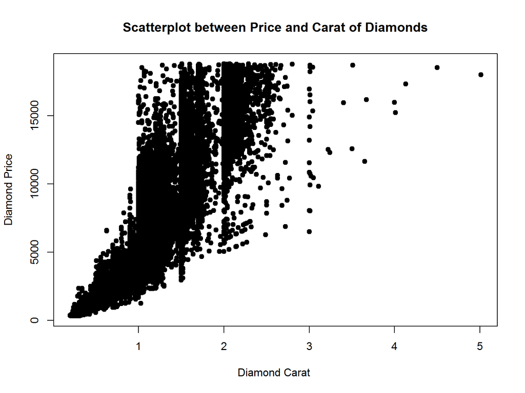